# Data Wrangling: Gathering, Assessing & Cleaning Project

**Udacity Data Analyst Nano Degree**

*Term 2: Data Wrangling*

*By Calvert Louden Jr.*

## Data Gathering Process:

```python
# importing the necessary libraries and/or modules for working with data frames
import numpy as np
import pandas as pd
from pandas import Series,DataFrame

# importing necessary libraries/modules for reading/requesting data from the web
import json
import os
import requests
import re

# importing the necessary libraries for visualizations
import matplotlib.pyplot as plt
% matplotlib inline
import matplotlib.ticker as ticker
import seaborn as sns
plt.style.use('seaborn')
```

```python
# reading in my twitter-archive-enhanced-2 csv file into a df using pandas '.read_csv()'
twt_ar_df = pd.read_csv('twitter-archive-enhanced-2.csv')
twt_ar_df.head()
```

|  | tweet_id | in_reply_to_status_id | in_reply_to_user_id | timestamp | source | text | retweeted_status_id | retweeted_status_user_id | retweeted_status_timestamp | expanded_urls | rating_numerator | rating_denominator | name | doggo | floofer | pupper | puppo |
| --- | --- | --- | --- | --- | --- | --- | --- | --- | --- | --- | --- | --- | --- | --- | --- | --- | --- |
| 0 | 892420643555336193 | NaN | NaN | 2017-08-01 16:23:56 +0000 | <a href="http://twitter.com/download/iphone" r... | This is Phineas. He's a mystical boy. Only eve... | NaN | NaN | NaN | https://twitter.com/dog_rates/status/892420643... | 13 | 10 | Phineas | None | None | None | None |
| 1 | 892177421306343426 | NaN | NaN | 2017-08-01 00:17:27 +0000 | <a href="http://twitter.com/download/iphone" r... | This is Tilly. She's just checking pup on you.... | NaN | NaN | NaN | https://twitter.com/dog_rates/status/892177421... | 13 | 10 | Tilly | None | None | None | None |
| 2 | 891815181378084864 | NaN | NaN | 2017-07-31 00:18:03 +0000 | <a href="http://twitter.com/download/iphone" r... | This is Archie. He is a rare Norwegian Pouncin... | NaN | NaN | NaN | https://twitter.com/dog_rates/status/891815181... | 12 | 10 | Archie | None | None | None | None |
| 3 | 891689557279858688 | NaN | NaN | 2017-07-30 15:58:51 +0000 | <a href="http://twitter.com/download/iphone" r... | This is Darla. She commenced a snooze mid meal... | NaN | NaN | NaN | https://twitter.com/dog_rates/status/891689557... | 13 | 10 | Darla | None | None | None | None |
| 4 | 891327558926688256 | NaN | NaN | 2017-07-29 16:00:24 +0000 | <a href="http://twitter.com/download/iphone" r... | This is Franklin. He would like you to stop ca... | NaN | NaN | NaN | https://twitter.com/dog_rates/status/891327558... | 12 | 10 | Franklin | None | None | None | None |

**Programmatically downloading the file from the internet**

```python
# first you have to import the 'requests' library so you can use the 'get()' function, import the os library as well
# so we can store the file we download in a folder

# creating a folder to store the downloaded file
folder_name = 'image_predictions'
if not os.path.exists(folder_name):
    os.makedirs(folder_name)

url = 'https://d17h27t6h515a5.cloudfront.net/topher/2017/August/599fd2ad_image-predictions/image-predictions.tsv'

response = requests.get(url)
response
```

```
<Response [200]>
```

```python
# writing the file content to file
with open(os.path.join(folder_name, url.split('/')[-1]), mode = 'wb') as file:
    file.write(response.content)
```

```python
# checking to make sure download worked
os.listdir(folder_name)
```

```
['image-predictions.tsv']
```

```python
# reading in my downloaded '.tsv' file using pandas '.read_csv()' function,
# making note to mention the separator parameter 'sep='\t'
img_prd_df = pd.read_csv('image_predictions/image-predictions.tsv', sep='\t', header=0)

img_prd_df.head()
```

|  | tweet_id | jpg_url | img_num | p1 | p1_conf | p1_dog | p2 | p2_conf | p2_dog | p3 | p3_conf | p3_dog |
| --- | --- | --- | --- | --- | --- | --- | --- | --- | --- | --- | --- | --- |
| 0 | 666020888022790149 | https://pbs.twimg.com/media/CT4udn0WwAA0aMy.jpg | 1 | Welsh_springer_spaniel | 0.465074 | True | collie | 0.156665 | True | Shetland_sheepdog | 0.061428 | True |
| 1 | 666029285002620928 | https://pbs.twimg.com/media/CT42GRgUYAA5iDo.jpg | 1 | redbone | 0.506826 | True | miniature_pinscher | 0.074192 | True | Rhodesian_ridgeback | 0.072010 | True |
| 2 | 666033412701032449 | https://pbs.twimg.com/media/CT4521TWwAEvMyu.jpg | 1 | German_shepherd | 0.596461 | True | malinois | 0.138584 | True | bloodhound | 0.116197 | True |
| 3 | 666044226329800704 | https://pbs.twimg.com/media/CT5Dr8HUEAA-lEu.jpg | 1 | Rhodesian_ridgeback | 0.408143 | True | redbone | 0.360687 | True | miniature_pinscher | 0.222752 | True |
| 4 | 666049248165822465 | https://pbs.twimg.com/media/CT5IQmsXIAAKY4A.jpg | 1 | miniature_pinscher | 0.560311 | True | Rottweiler | 0.243682 | True | Doberman | 0.154629 | True |

**Querying Twitter's API**

```python
import tweepy

consumer_key = 'Consumer Key'
consumer_secret = 'Consumer Secret'
access_token = 'Access Token'
access_secret = 'Access Secret'

auth = tweepy.OAuthHandler(consumer_key, consumer_secret)
auth.set_access_token(access_token, access_secret)

api = tweepy.API(auth_handler = auth, parser = tweepy.parsers.JSONParser(), wait_on_rate_limit = True,
                 wait_on_rate_limit_notify = True)
```

```python
# creating a series from 'tweet_id' column of the twitter_archived_enhanced data; I'll use this as a list to iterate
# through when querying Twitter's API by tweet_id later
twt_ids = list(twt_ar_df['tweet_id'])

tweet_errors = {}
```

```python
print(type(twt_ids[0]))
```

```
<class 'int'>
```

```python
# taking a look at the tweet status data in its entirety
tweet = api.get_status(892420643555336193, tweet_mode = 'extended', count = 1)
print(tweet)
```

```
{'created_at': 'Tue Aug 01 16:23:56 +0000 2017', 'id': 892420643555336193, 'id_str': '892420643555336193', 'full_text': "This is Phineas. He's a mystical boy. Only ever appears in the hole of a donut. 13/10 https://t.co/MgUWQ76dJU", 'truncated': False, 'display_text_range': [0, 85], 'entities': {'ha…
```

```python
# checking the data type of 'id', which is tweet id
print(type(tweet['id']))
```

```
<class 'int'>
```

```python
# pulling some data from the tweet
tweet['full_text']
```

```
"This is Phineas. He's a mystical boy. Only ever appears in the hole of a donut. 13/10 https://t.co/MgUWQ76dJU"
```

**Querying Twitter's API**

```python
# creating the 'tweet_data_lst' list, which will have the specified tweet data appended to it
tweet_data_lst = []
count = 0
tweet_errors = {}

with open('tweet_json.txt', 'w') as outfile:
    for id in twt_ids:
        count += 1
        print(str(count) + ':' + str(id))
        print('Success')
        try:
            tweet = api.get_status(id, tweet_mode = 'extended')
            favorite = tweet['favorite_count']
            favorited = tweet['favorited']
            retweets = tweet['retweet_count']
            retweeted = tweet['retweeted']
            # appending json tweet dictionary to the empty data frame tweet list
            tweet_data_lst.append({'tweet_id': int(id),
                                   'favorites': int(favorite),
                                   'favorited': favorited,
                                   'retweets': int(retweets),
                                   'retweeted': retweeted
                                  })
            json.dump(tweet_data_lst[-1], outfile)
            outfile.write('\n')
        except (Exception, tweepy.TweepError) as e:
            print('Fail')
            tweet_errors[id] = e
        pass
```

[output not shown]

[output cut: 1757 more lines]

[output not shown]

```
Rate limit reached. Sleeping for: 702
```

[output not shown]

[output cut: 1749 more lines]

[output not shown]

```
Rate limit reached. Sleeping for: 739
```

[output not shown]

[output cut: 1057 more lines]

[output not shown]

```python
print(len(tweet_data_lst))
print(len(tweet_errors))
```

```
2340
16
```

```python
# creating a data frame from the 'tweet_data_lst' dictionary list
twt_df = pd.DataFrame(tweet_data_lst, columns = ['tweet_id', 'favorites', 'favorited', 'retweets', 'retweeted'])

twt_df.head()
```

|  | tweet_id | favorites | favorited | retweets | retweeted |
| --- | --- | --- | --- | --- | --- |
| 0 | 892420643555336193 | 37997 | False | 8308 | False |
| 1 | 892177421306343426 | 32628 | False | 6138 | False |
| 2 | 891815181378084864 | 24551 | False | 4062 | False |
| 3 | 891689557279858688 | 41348 | False | 8453 | False |
| 4 | 891327558926688256 | 39526 | False | 9152 | False |

```python
twt_df.info()
```

```
<class 'pandas.core.frame.DataFrame'>
RangeIndex: 2340 entries, 0 to 2339
Data columns (total 5 columns):
tweet_id     2340 non-null int64
favorites    2340 non-null int64
favorited    2340 non-null bool
retweets     2340 non-null int64
retweeted    2340 non-null bool
dtypes: bool(2), int64(3)
memory usage: 59.5 KB
```

## Assessing My Data

### Twitter_arch DF

```python
twt_ar_df.info()
```

```
<class 'pandas.core.frame.DataFrame'>
RangeIndex: 2356 entries, 0 to 2355
Data columns (total 17 columns):
tweet_id                      2356 non-null int64
in_reply_to_status_id         78 non-null float64
in_reply_to_user_id           78 non-null float64
timestamp                     2356 non-null object
source                        2356 non-null object
text                          2356 non-null object
retweeted_status_id           181 non-null float64
retweeted_status_user_id      181 non-null float64
retweeted_status_timestamp    181 non-null object
expanded_urls                 2297 non-null object
rating_numerator              2356 non-null int64
rating_denominator            2356 non-null int64
name                          2356 non-null object
doggo                         2356 non-null object
floofer                       2356 non-null object
pupper                        2356 non-null object
puppo                         2356 non-null object
dtypes: float64(4), int64(3), object(10)
memory usage: 313.0+ KB
```

```python
# selecting 5 random observations to review
twt_ar_df.sample(5)
```

|  | tweet_id | in_reply_to_status_id | in_reply_to_user_id | timestamp | source | text | retweeted_status_id | retweeted_status_user_id | retweeted_status_timestamp | expanded_urls | rating_numerator | rating_denominator | name | doggo | floofer | pupper | puppo |
| --- | --- | --- | --- | --- | --- | --- | --- | --- | --- | --- | --- | --- | --- | --- | --- | --- | --- |
| 1437 | 697242256848379904 | NaN | NaN | 2016-02-10 02:14:42 +0000 | <a href="http://twitter.com/download/iphone" r... | This is Oakley. He has a massive tumor growing... | NaN | NaN | NaN | https://twitter.com/dog_rates/status/697242256... | 10 | 10 | Oakley | None | None | None | None |
| 1720 | 680145970311643136 | NaN | NaN | 2015-12-24 22:00:10 +0000 | <a href="http://twitter.com/download/iphone" r... | Say hello to Kawhi. He was doing fine until hi... | NaN | NaN | NaN | https://twitter.com/dog_rates/status/680145970... | 10 | 10 | Kawhi | None | None | pupper | None |
| 451 | 818627210458333184 | NaN | NaN | 2017-01-10 01:15:10 +0000 | <a href="http://twitter.com/download/iphone" r... | Meet Wafer. He represents every fiber of my be... | NaN | NaN | NaN | https://twitter.com/dog_rates/status/818627210... | 13 | 10 | Wafer | None | None | None | None |
| 2071 | 671115716440031232 | NaN | NaN | 2015-11-29 23:57:10 +0000 | <a href="http://twitter.com/download/iphone" r... | Meet Phred. He isn't steering, looking at the ... | NaN | NaN | NaN | https://twitter.com/dog_rates/status/671115716... | 6 | 10 | Phred | None | None | None | None |
| 805 | 772114945936949249 | NaN | NaN | 2016-09-03 16:52:02 +0000 | <a href="http://twitter.com/download/iphone" r... | This is Finn. He's very nervous for the game. ... | NaN | NaN | NaN | https://twitter.com/dog_rates/status/772114945... | 10 | 10 | Finn | None | None | None | None |

```python
# checking for duplicated rows
sum(twt_ar_df.duplicated())
```

```
0
```

### Twitter Archive DF Identified Issues:

**Dirty Data:** content issues, also known as *low quality data*

- completeness, i.e. missing data/values
- inaccurate data
- corrupted data
- duplicate data

**Data Quality Dimensions:**

*Completeness Issues:*

- `in_reply_to_status_id` only has 78 observations(tweets) while the data set has a total of 2356 observations; I'll eventually remove these, as they are not part of the original tweet data
- `in_reply_to_user_id` only has 78 observations(tweets) while the data set has a total of 2356 observations; I'll eventually remove these, as they are not part of the original tweet data
- `retweeted_status_id` only has 181 observations(tweets) while the data set has a total of 2356 observations; I'll eventually remove these, as they are not part of the original tweet data
- `retweeted_status_user_id` only has 181 observations(tweets) while the data set has a total of 2356  
  observations; I'll eventually remove these, as they are not part of the original tweet data
- `retweeted_status_timestamp` only has 181 observations(tweets) while the data set has a total of 2356 observations; I'll eventually remove these, as they are not part of the original tweet data
- `expanded_urls` only has 2297 observations(tweets) while the data set has a total of 2356 observations
- `name` column, although 2356 observations are present, after visually inspecting the data, some 'name' values are replaced with 'None', so in essence the data is missing

*Inaccurate Data:*

- `rating_numerator` has multiple incorrect values for observations based on `text` data
- `expanded_urls` has some observations with incorrect(non-twitter) urls; there's a standard convention for tweet urls
- `text` column contains come RTs, or retweets. We only want original ratings so the retweets will have to be removed
- `name` has inaccurate values in many observations

*Consistency*

- `source` column has html coding present; not very clean for presentation. "https://..." will be set as the standard format
- `text` column has 'https://...' web address present in data
- `retweeted_status_timestamp` is listed as an object type, but displayed as date/time
- `timestamp` is listed as an object type but displayed as date/time
- `in_reply_to_status_id` & `in_reply_to_user_id` are currently listed as type float(64) and should be integers
- `retweeted_status_id` & `retweeted_status_user_id` are currently listed as type float(64) and should be integers
- `rating_numerator` should be of type float(64), currently an int. This is due to some ratings containing decimal places

**Messy Data:** structural issues, also known as *untidy data*

- each variable forms a column
- each observation forms a row
- each observational unit forms a table

*Structural Issues:*

- (`doggo`, `floofer`, `pupper`, and `puppo`) columns, although 2356 observations are present, after visually inspecting the data, this is a categorical variable, which can be condenced into 1 column.

### Image Prediction DF

```python
img_prd_df.info()
```

```
<class 'pandas.core.frame.DataFrame'>
RangeIndex: 2075 entries, 0 to 2074
Data columns (total 12 columns):
tweet_id    2075 non-null int64
jpg_url     2075 non-null object
img_num     2075 non-null int64
p1          2075 non-null object
p1_conf     2075 non-null float64
p1_dog      2075 non-null bool
p2          2075 non-null object
p2_conf     2075 non-null float64
p2_dog      2075 non-null bool
p3          2075 non-null object
p3_conf     2075 non-null float64
p3_dog      2075 non-null bool
dtypes: bool(3), float64(3), int64(2), object(4)
memory usage: 152.1+ KB
```

```python
# getting a random sample of observations
img_prd_df.sample(5)
```

|  | tweet_id | jpg_url | img_num | p1 | p1_conf | p1_dog | p2 | p2_conf | p2_dog | p3 | p3_conf | p3_dog |
| --- | --- | --- | --- | --- | --- | --- | --- | --- | --- | --- | --- | --- |
| 1296 | 752173152931807232 | https://pbs.twimg.com/media/CnBBfNuWcAAkOgO.jpg | 1 | Labrador_retriever | 0.527659 | True | German_shepherd | 0.174765 | True | Chihuahua | 0.045525 | True |
| 9 | 666058600524156928 | https://pbs.twimg.com/media/CT5Qw94XAAA_2dP.jpg | 1 | miniature_poodle | 0.201493 | True | komondor | 0.192305 | True | soft-coated_wheaten_terrier | 0.082086 | True |
| 1117 | 725786712245440512 | https://pbs.twimg.com/media/ChKDKmIWIAIJP_e.jpg | 1 | chow | 0.335761 | True | Samoyed | 0.167173 | True | kuvasz | 0.145715 | True |
| 96 | 667724302356258817 | https://pbs.twimg.com/media/CUQ7tv3W4AA3KlI.jpg | 1 | ibex | 0.619098 | False | bighorn | 0.125119 | False | ram | 0.074673 | False |
| 342 | 672256522047614977 | https://pbs.twimg.com/media/CVRVvRMWEAIBKOP.jpg | 1 | ostrich | 0.999004 | False | Arabian_camel | 0.000512 | False | llama | 0.000147 | False |

```python
# checking for duplicated rows
sum(img_prd_df.duplicated())
```

```
0
```

```python
# checking for any duplicate tweet_ids
len(img_prd_df['tweet_id'].unique())
```

```
2075
```

### Image Prediction DF Identified Issues

**Dirty Data:** content issues, also known as *low quality data*

- completeness, i.e. missing data/values
- inaccurate data
- corrupted data
- duplicate data

**Data Quality Dimensions**

*Consistency:*

- some values in `p3_conf` do not fit the standard format for `_conf` values displayed: 0.xxxxxx
- some values in the p1, p2, or p3 columns need to have the '_' removed and replaced with ' ', spaces.

**Messy Data:** structural issues, also known as *untidy data*

- each variable forms a column
- each observation forms a row
- each observational unit forms a table

*Structural Issues:*

- `p1`, `p1_conf`, `p1_dog`, `p2`, `p2_conf`, `p2_dog`, `p3`, `p3_conf`, `p3_dog` are all categorical column names. These 9 columns can be condensed down to 3 columns:
  - 'Predictions' can hold `p1`, `p2`, and `p3` categories.
  - 'Prediction Confidence' can hold `p1_conf`, `p2_conf` and `p3_conf` values.
  - 'Prediction Breed of Dog' can hold `p1_dog`, `p2_dog` and `p3_dog` prediction outcomes.

### Tweet Info (twt_df) DF

```python
twt_df.info()
```

```
<class 'pandas.core.frame.DataFrame'>
RangeIndex: 2340 entries, 0 to 2339
Data columns (total 5 columns):
tweet_id     2340 non-null int64
favorites    2340 non-null int64
favorited    2340 non-null bool
retweets     2340 non-null int64
retweeted    2340 non-null bool
dtypes: bool(2), int64(3)
memory usage: 59.5 KB
```

```python
# generating a sample to look at
twt_df.sample(5)
```

|  | tweet_id | favorites | favorited | retweets | retweeted |
| --- | --- | --- | --- | --- | --- |
| 1911 | 674051556661161984 | 1471 | False | 500 | False |
| 1305 | 706346369204748288 | 3605 | False | 981 | False |
| 1228 | 711968124745228288 | 8399 | False | 2451 | False |
| 2141 | 669583744538451968 | 1513 | False | 949 | False |
| 1272 | 708356463048204288 | 3766 | False | 1418 | False |

```python
twt_df.describe()
```

|  | tweet_id | favorites | retweets |
| --- | --- | --- | --- |
| count | 2.340000e+03 | 2340.000000 | 2340.000000 |
| mean | 7.422176e+17 | 7952.697436 | 2925.927350 |
| std | 6.832564e+16 | 12318.340736 | 4928.872499 |
| min | 6.660209e+17 | 0.000000 | 0.000000 |
| 25% | 6.783394e+17 | 1371.500000 | 587.000000 |
| 50% | 7.186224e+17 | 3457.500000 | 1366.500000 |
| 75% | 7.986954e+17 | 9730.500000 | 3409.250000 |
| max | 8.924206e+17 | 164076.000000 | 83532.000000 |

```python
# checking for duplicate rows
sum(twt_df.duplicated())
```

```
0
```

### Tweet Info DF Identified Issues

**Dirty Data:** content issues, also known as *low quality data*

- completeness, i.e. missing data/values
- inaccurate data
- corrupted data
- duplicate data

**Data Quality Dimensions**

*Accuracy:*

- some values in the `favorites` column, have '0' as their value. Though this may be inaccurate data (not sure  
  yet), it is valid as it adheres to the defined schema.
- I only found 1 `retweets` value of '0' so far in my exploration

## Cleaning My Data

### Twitter Archive DF

**Data Quality Dimensions:**

*Completeness Issues:*

- `in_reply_to_status_id`: Remove data from set
- `in_reply_to_user_id`: Remove data from set
- `retweeted_status_id`: Remove data from set
- `retweeted_status_user_id`: Remove data from set
- `retweeted_status_timestamp`: Remove data from set
- `expanded_urls` only has 2297 observations(tweets) while the data set has a total of 2356 observations

*Inaccurate Data:*

- `expanded_urls` has some observations with incorrect(non-twitter) urls; there's a standard convention for tweet urls
- `text` column contains come RTs, or retweets. We only want original ratings so the retweets will have to be removed
- `rating_numerator` column has multiple observations with inaccurate ratings
- `name` column has some observations where 'None' is displayed but a name is provided in the tweet text

*Consistency*

- `source`: remove the html tags at the beginning and end of tweet source url
- `text` column has 'https://...' web address present in data
- `timestamp` column is displayed as a date/time object but is actually of data type object, or string

```python
# first things first, before any cleaning is attempted, I make a copy of my data frame
twt_ar_df_cln = twt_ar_df.copy()
```

```python
twt_ar_df_cln.head(3)
```

|  | tweet_id | in_reply_to_status_id | in_reply_to_user_id | timestamp | source | text | retweeted_status_id | retweeted_status_user_id | retweeted_status_timestamp | expanded_urls | rating_numerator | rating_denominator | name | doggo | floofer | pupper | puppo |
| --- | --- | --- | --- | --- | --- | --- | --- | --- | --- | --- | --- | --- | --- | --- | --- | --- | --- |
| 0 | 892420643555336193 | NaN | NaN | 2017-08-01 16:23:56 +0000 | <a href="http://twitter.com/download/iphone" r... | This is Phineas. He's a mystical boy. Only eve... | NaN | NaN | NaN | https://twitter.com/dog_rates/status/892420643... | 13 | 10 | Phineas | None | None | None | None |
| 1 | 892177421306343426 | NaN | NaN | 2017-08-01 00:17:27 +0000 | <a href="http://twitter.com/download/iphone" r... | This is Tilly. She's just checking pup on you.... | NaN | NaN | NaN | https://twitter.com/dog_rates/status/892177421... | 13 | 10 | Tilly | None | None | None | None |
| 2 | 891815181378084864 | NaN | NaN | 2017-07-31 00:18:03 +0000 | <a href="http://twitter.com/download/iphone" r... | This is Archie. He is a rare Norwegian Pouncin... | NaN | NaN | NaN | https://twitter.com/dog_rates/status/891815181... | 12 | 10 | Archie | None | None | None | None |

**Removing any Non-Original tweets from the data set**

*Define*

- Remove: only selecting original tweets for my data set; per guidelines, no retweets should be present within the data. Using `.info()`, the programmatic assessment method, on my data frame, I'm able to see what columnar data might be associated with retweets. This could help me identify which data to drop quicker.

*Code*

```python
# locating non-original tweet data and storing it in a variable to pass to the '.drop()' function later
rep_st_id = twt_ar_df_cln[twt_ar_df_cln["in_reply_to_status_id"].notnull()]
```

```python
# removing any non-original tweet from the data set
twt_ar_df_cln = twt_ar_df_cln.drop(rep_st_id.index)
```

```python
# locating non-original (retweet) data and storing it in a variable to pass to the '.drop()' function later
rtwd_st_id = twt_ar_df_cln[twt_ar_df_cln['retweeted_status_id'].notnull()]
```

```python
# removing 'retweeted_' data from the data set
twt_ar_df_cln = twt_ar_df_cln.drop(rtwd_st_id.index)
```

*Test*

```python
twt_ar_df_cln.info()
```

```
<class 'pandas.core.frame.DataFrame'>
Int64Index: 2097 entries, 0 to 2355
Data columns (total 17 columns):
tweet_id                      2097 non-null int64
in_reply_to_status_id         0 non-null float64
in_reply_to_user_id           0 non-null float64
timestamp                     2097 non-null object
source                        2097 non-null object
text                          2097 non-null object
retweeted_status_id           0 non-null float64
retweeted_status_user_id      0 non-null float64
retweeted_status_timestamp    0 non-null object
expanded_urls                 2094 non-null object
rating_numerator              2097 non-null int64
rating_denominator            2097 non-null int64
name                          2097 non-null object
doggo                         2097 non-null object
floofer                       2097 non-null object
pupper                        2097 non-null object
puppo                         2097 non-null object
dtypes: float64(4), int64(3), object(10)
memory usage: 294.9+ KB
```

**Expanded URLs**

*Define*

- Remove duplicate web addresses within values for `expanded_urls` to just 1 and store in new column `tweet_status_url`. Then drop `expanded_url` column.

*Code*

```python
# extending the character length of my dataframe columns
pd.options.display.max_colwidth=250
```

```python
twt_ar_df_cln['expanded_urls'].sample(5)
```

```
520                                                                                                                             https://twitter.com/dog_rates/status/810254108431155201/photo/1
139                                                             https://twitter.com/dog_rates/status/865359393868664832/photo/1,https://twitter.com/dog_rates/status/865359393868664832/photo/1
98      https://www.gofundme.com/help-my-baby-sierra-get-better,https://twitter.com/dog_rates/status/873213775632977920/photo/1,https://twitter.com/dog_rates/status/873213775632977920/photo/1
2176                                                                                                                            https://twitter.com/dog_rates/status/669203728096960512/photo/1
743                                                                                                                             https://twitter.com/dog_rates/status/780459368902959104/photo/1
Name: expanded_urls, dtype: object
```

```python
# removing the duplicate urls within rows of the 'expanded_urls' column by using a 'for' loop to iterate through
# tweet_ids. Within the loop, I'll use the '.loc' to index the rows by label, or tweet_id, where there I'll set
# the value for the new column created 'tweet_status_url'

for id in twt_ids:
    cnt = 1
    twt_ar_df_cln.loc[twt_ar_df_cln.tweet_id == id, 'tweet_status_url'] = (('https://twitter.com/dog_rates/status/') + str(id) + '/' + 'photo' + '/' + str(1))
    cnt += 1
```

```python
# deleting the 'expanded_urls' column
del twt_ar_df_cln['expanded_urls']
```

*Test*

```python
twt_ar_df_cln['tweet_status_url'].sample(5)
```

```
375     https://twitter.com/dog_rates/status/828361771580813312/photo/1
1784    https://twitter.com/dog_rates/status/677662372920729601/photo/1
1189    https://twitter.com/dog_rates/status/718246886998687744/photo/1
1711    https://twitter.com/dog_rates/status/680497766108381184/photo/1
1811    https://twitter.com/dog_rates/status/676819651066732545/photo/1
Name: tweet_status_url, dtype: object
```

```python
twt_ar_df_cln.info()
```

```
<class 'pandas.core.frame.DataFrame'>
Int64Index: 2097 entries, 0 to 2355
Data columns (total 17 columns):
tweet_id                      2097 non-null int64
in_reply_to_status_id         0 non-null float64
in_reply_to_user_id           0 non-null float64
timestamp                     2097 non-null object
source                        2097 non-null object
text                          2097 non-null object
retweeted_status_id           0 non-null float64
retweeted_status_user_id      0 non-null float64
retweeted_status_timestamp    0 non-null object
rating_numerator              2097 non-null int64
rating_denominator            2097 non-null int64
name                          2097 non-null object
doggo                         2097 non-null object
floofer                       2097 non-null object
pupper                        2097 non-null object
puppo                         2097 non-null object
tweet_status_url              2097 non-null object
dtypes: float64(4), int64(3), object(10)
memory usage: 294.9+ KB
```

**`rating_numerator` column has incorrect values for multiple observations**

*Define*

- extract the correct rating value from text for the `rating_numerator` column using RegEx

*Code*

```python
twt_ar_df_cln.loc[twt_ar_df_cln.tweet_id == 883482846933004288]
```

|  | tweet_id | in_reply_to_status_id | in_reply_to_user_id | timestamp | source | text | retweeted_status_id | retweeted_status_user_id | retweeted_status_timestamp | rating_numerator | rating_denominator | name | doggo | floofer | pupper | puppo | tweet_status_url |
| --- | --- | --- | --- | --- | --- | --- | --- | --- | --- | --- | --- | --- | --- | --- | --- | --- | --- |
| 45 | 883482846933004288 | NaN | NaN | 2017-07-08 00:28:19 +0000 | <a href="http://twitter.com/download/iphone" rel="nofollow">Twitter for iPhone</a> | This is Bella. She hopes her smile made you smile. If not, she is also offering you her favorite monkey. 13.5/10 https://t.co/qjrljjt948 | NaN | NaN | NaN | 5 | 10 | Bella | None | None | None | None | https://twitter.com/dog_rates/status/883482846933004288/photo/1 |

```python
# extracting the true dog ratings from the text column and placing it in a new column 'extract'
twt_ar_df_cln['extract'] = twt_ar_df_cln['text'].str.extract('(\d+?\.?\d?\/\d+)', expand=True)
```

```python
# replacing the '/' with a ','(comma) so I can use the '.split()' method later
twt_ar_df_cln['extract'] = twt_ar_df_cln['extract'].str.replace('/', ' ')
```

```python
# splitting my values in the extract column so they can be accessed individually
twt_ar_df_cln['extract'] = twt_ar_df_cln['extract'].str.split()
```

```python
twt_ar_df_cln['extract'] = twt_ar_df_cln['extract'].astype(str)
```

```python
# extracting the first value in the tuple, which is the rating for the dog in the photo,
# and setting the 'rating_numerator' column values correctly
twt_ar_df_cln['rating_numerator'] = twt_ar_df_cln['extract'].str.extract('(\d+\.?\d)', expand=True)
```

```python
# checking for any null values
sum(twt_ar_df_cln['rating_numerator'].isnull())
```

```
1
```

```python
# deleting my 'extract' column
twt_ar_df_cln.drop(['extract'], axis=1, inplace=True)
```

*Test*

```python
# checking to make sure the correct ratings from 'text' were mapped to 'rating_numerator' column
twt_ar_df_cln.loc[twt_ar_df_cln.tweet_id == 883482846933004288]
```

|  | tweet_id | in_reply_to_status_id | in_reply_to_user_id | timestamp | source | text | retweeted_status_id | retweeted_status_user_id | retweeted_status_timestamp | rating_numerator | rating_denominator | name | doggo | floofer | pupper | puppo | tweet_status_url |
| --- | --- | --- | --- | --- | --- | --- | --- | --- | --- | --- | --- | --- | --- | --- | --- | --- | --- |
| 45 | 883482846933004288 | NaN | NaN | 2017-07-08 00:28:19 +0000 | <a href="http://twitter.com/download/iphone" rel="nofollow">Twitter for iPhone</a> | This is Bella. She hopes her smile made you smile. If not, she is also offering you her favorite monkey. 13.5/10 https://t.co/qjrljjt948 | NaN | NaN | NaN | 13.5 | 10 | Bella | None | None | None | None | https://twitter.com/dog_rates/status/883482846933004288/photo/1 |

```python
twt_ar_df_cln.info()
```

```
<class 'pandas.core.frame.DataFrame'>
Int64Index: 2097 entries, 0 to 2355
Data columns (total 17 columns):
tweet_id                      2097 non-null int64
in_reply_to_status_id         0 non-null float64
in_reply_to_user_id           0 non-null float64
timestamp                     2097 non-null object
source                        2097 non-null object
text                          2097 non-null object
retweeted_status_id           0 non-null float64
retweeted_status_user_id      0 non-null float64
retweeted_status_timestamp    0 non-null object
rating_numerator              2096 non-null object
rating_denominator            2097 non-null int64
name                          2097 non-null object
doggo                         2097 non-null object
floofer                       2097 non-null object
pupper                        2097 non-null object
puppo                         2097 non-null object
tweet_status_url              2097 non-null object
dtypes: float64(4), int64(2), object(11)
memory usage: 294.9+ KB
```

**`rating_numerator` is of wrong data type int(64) and should be a float(64)**

*Define*

- change data type to float

*Code*

```python
# setting the data type of the 'rating_numerator' column to float(64) b/c of the decimal value rating
# in the set
twt_ar_df_cln['rating_numerator'] = twt_ar_df_cln['rating_numerator'].astype(float)
```

*Test*

```python
print((twt_ar_df_cln['rating_numerator'].dtype))
```

```
float64
```

**Removing HTML tags from web source url in `source` column**

*Define*

- removing HTML tags by using the `.str.replace()` method

*Code*

```python
# removing the start HTML tag, '<a href='
twt_ar_df_cln['source'] = twt_ar_df_cln['source'].str.replace('<a href=', '')
```

```python
# removing the end HTML tag, '</a>'
twt_ar_df_cln['source'] = twt_ar_df_cln['source'].str.replace('</a>', '')
```

```python
# removing the last '>' character from the string
twt_ar_df_cln['source'] = twt_ar_df_cln['source'].str.replace('>', ' ')
```

*Test*

```python
twt_ar_df_cln['source'].sample(5)
```

```
1640                       "http://vine.co" rel="nofollow" Vine - Make a Scene
730     "http://twitter.com/download/iphone" rel="nofollow" Twitter for iPhone
848     "http://twitter.com/download/iphone" rel="nofollow" Twitter for iPhone
806     "http://twitter.com/download/iphone" rel="nofollow" Twitter for iPhone
881                        "http://vine.co" rel="nofollow" Vine - Make a Scene
Name: source, dtype: object
```

**`text` column has 'https://...' web address present in data**

*Define*

- Remove web addresses from `text` column

*Code*

```python
twt_ar_df_cln.sample(1)
```

|  | tweet_id | in_reply_to_status_id | in_reply_to_user_id | timestamp | source | text | retweeted_status_id | retweeted_status_user_id | retweeted_status_timestamp | rating_numerator | rating_denominator | name | doggo | floofer | pupper | puppo | tweet_status_url |
| --- | --- | --- | --- | --- | --- | --- | --- | --- | --- | --- | --- | --- | --- | --- | --- | --- | --- |
| 1677 | 682059653698686977 | NaN | NaN | 2015-12-30 04:44:28 +0000 | "http://twitter.com/download/iphone" rel="nofollow" Twitter for iPhone | This is Tess. Her main passions are shelves and baking too many cookies. 11/10 https://t.co/IriJlVZ6m4 | NaN | NaN | NaN | 11.0 | 10 | Tess | None | None | None | None | https://twitter.com/dog_rates/status/682059653698686977/photo/1 |

```python
# removing all web addresses from the 'text' column
twt_ar_df_cln['text'] = twt_ar_df_cln['text'].str.replace('https:.*', '')
```

*Test*

```python
twt_ar_df_cln.head(1)
```

|  | tweet_id | in_reply_to_status_id | in_reply_to_user_id | timestamp | source | text | retweeted_status_id | retweeted_status_user_id | retweeted_status_timestamp | rating_numerator | rating_denominator | name | doggo | floofer | pupper | puppo | tweet_status_url |
| --- | --- | --- | --- | --- | --- | --- | --- | --- | --- | --- | --- | --- | --- | --- | --- | --- | --- |
| 0 | 892420643555336193 | NaN | NaN | 2017-08-01 16:23:56 +0000 | "http://twitter.com/download/iphone" rel="nofollow" Twitter for iPhone | This is Phineas. He's a mystical boy. Only ever appears in the hole of a donut. 13/10 | NaN | NaN | NaN | 13.0 | 10 | Phineas | None | None | None | None | https://twitter.com/dog_rates/status/892420643555336193/photo/1 |

**Changing `timestamp` column data type**

*Define*

- column, `timestamp` is currently listed as an object data type, or string in Python. However, its displayed as a date time object. I'll change the data type to date/time

*Code*

```python
# converting `timestamp` column to datetime object
twt_ar_df_cln['timestamp'] = pd.to_datetime(twt_ar_df_cln['timestamp'])
```

*Test*

```python
twt_ar_df_cln.info()
```

```
<class 'pandas.core.frame.DataFrame'>
Int64Index: 2097 entries, 0 to 2355
Data columns (total 17 columns):
tweet_id                      2097 non-null int64
in_reply_to_status_id         0 non-null float64
in_reply_to_user_id           0 non-null float64
timestamp                     2097 non-null datetime64[ns]
source                        2097 non-null object
text                          2097 non-null object
retweeted_status_id           0 non-null float64
retweeted_status_user_id      0 non-null float64
retweeted_status_timestamp    0 non-null object
rating_numerator              2096 non-null float64
rating_denominator            2097 non-null int64
name                          2097 non-null object
doggo                         2097 non-null object
floofer                       2097 non-null object
pupper                        2097 non-null object
puppo                         2097 non-null object
tweet_status_url              2097 non-null object
dtypes: datetime64[ns](1), float64(5), int64(2), object(9)
memory usage: 294.9+ KB
```

**`name` column has inaccurate values**

*Define*

- replace existing name values with correctly extracted names from text using RegEx

*Code*

```python
twt_ar_df_cln.sample(1)
```

|  | tweet_id | in_reply_to_status_id | in_reply_to_user_id | timestamp | source | text | retweeted_status_id | retweeted_status_user_id | retweeted_status_timestamp | rating_numerator | rating_denominator | name | doggo | floofer | pupper | puppo | tweet_status_url |
| --- | --- | --- | --- | --- | --- | --- | --- | --- | --- | --- | --- | --- | --- | --- | --- | --- | --- |
| 363 | 829374341691346946 | NaN | NaN | 2017-02-08 17:00:26 | "http://twitter.com/download/iphone" rel="nofollow" Twitter for iPhone | This is Astrid. She's a guide doggo in training. 13/10 would follow anywhere | NaN | NaN | NaN | 13.0 | 10 | Astrid | doggo | None | None | None | https://twitter.com/dog_rates/status/829374341691346946/photo/1 |

- **'This is...' Pattern**

```python
# this extraction handles names after 'This is...' ; Checking the count(number) of values or names in the column
twt_ar_df_cln['text'].str.extract('([Tt]his is\s([A-Z]\w+))', expand=True).count()
```

```
0    1079
1    1079
dtype: int64
```

```python
# this extraction handles names after 'This is...'
this_lst = twt_ar_df_cln['text'].str.extract('([Tt]his is\s([A-Z]\w+))', expand=True)
```

```python
this_lst[this_lst[1].notnull()].sample(5)
```

|  | 0 | 1 |
| --- | --- | --- |
| 178 | This is Oscar | Oscar |
| 1987 | This is Oscar | Oscar |
| 296 | This is Lucy | Lucy |
| 134 | This is Lili | Lili |
| 1541 | This is Lucy | Lucy |

```python
# confirming my count
len(this_lst[this_lst[1].notnull()])
```

```
1079
```

- **'Named...' Pattern**

```python
# this extraction handles names after 'Named...' ; Checking the count(number) of values or names in the column
twt_ar_df_cln['text'].str.extract('([Nn]amed\s([A-Z]\w+))', expand=True).count()
```

```
0    23
1    23
dtype: int64
```

```python
nmd_lst = twt_ar_df_cln['text'].str.extract('([Nn]amed\s([A-Z]\w+))', expand=True)
```

```python
nmd_lst[nmd_lst[1].notnull()].sample(5)
```

|  | 0 | 1 |
| --- | --- | --- |
| 2218 | named Chuk | Chuk |
| 1853 | named Wylie | Wylie |
| 2128 | named Hemry | Hemry |
| 2125 | named Cherokee | Cherokee |
| 2273 | named Kohl | Kohl |

```python
# checking my count
len(nmd_lst[nmd_lst[1].notnull()])
```

```
23
```

- **'Meet...' Pattern**

```python
# this extraction handles names after 'Meet...' ; Checking the count(number) of values or names in the column
twt_ar_df_cln['text'].str.extract('([Mm]eet\s([A-Z]\w+))', expand=True).count()
```

```
0    216
1    216
dtype: int64
```

```python
met_lst = twt_ar_df_cln['text'].str.extract('([Mm]eet\s([A-Z]\w+))', expand=True)
```

```python
met_lst[met_lst[1].notnull()].sample(5)
```

|  | 0 | 1 |
| --- | --- | --- |
| 1067 | Meet Baloo | Baloo |
| 312 | Meet Lola | Lola |
| 2275 | Meet Cupcake | Cupcake |
| 2203 | Meet Hanz | Hanz |
| 2160 | Meet Kollin | Kollin |

```python
len(met_lst[met_lst[1].notnull()])
```

```
216
```

- **'Hello to...' Pattern**

```python
# this extraction handles names after 'Hello to...' Checking the count(number) of values or names in the column
twt_ar_df_cln['text'].str.extract('([Hh]ello [i]?to?[s]?[here]?\s([A-Z]\w+))', expand=True).count()
```

```
0    93
1    93
dtype: int64
```

```python
hel_lst = twt_ar_df_cln['text'].str.extract('([Hh]ello [i]?to?[s]?[here]?\s([A-Z]\w+))', expand=True)
```

```python
hel_lst[hel_lst[1].notnull()].sample(5)
```

|  | 0 | 1 |
| --- | --- | --- |
| 823 | hello to Carbon | Carbon |
| 1614 | hello to Petrick | Petrick |
| 659 | hello to Levi | Levi |
| 1240 | hello to Olive | Olive |
| 1396 | hello to Nala | Nala |

```python
len(hel_lst[hel_lst[1].notnull()])
```

```
93
```

- **Here is...' Pattern**

```python
twt_ar_df_cln['text'].str.extract('([Hh]ere is\s([A-Z]\w+))', expand=True).count()
```

```
0    3
1    3
dtype: int64
```

```python
her_lst = twt_ar_df_cln['text'].str.extract('([Hh]ere is\s([A-Z]\w+))', expand=True)
```

```python
her_lst[her_lst[1].notnull()].sample(3)
```

|  | 0 | 1 |
| --- | --- | --- |
| 2297 | Here is Dave | Dave |
| 492 | Here is Atlas | Atlas |
| 2262 | Here is George | George |

```python
len(her_lst[her_lst[1].notnull()])
```

```
3
```

```python
# mapping the 'name' column with the extracted names from text.
twt_ar_df_cln['name'] = twt_ar_df_cln['text'].str.extract('([Tt]his is|[Nn]amed|[Mm]eet|\
                                                            [Hh]ello to|[Hh]ere is)\s([A-Z]\w+)', expand=True)[1]
```

*Test*

```python
twt_ar_df_cln.head(25)
```

|  | tweet_id | in_reply_to_status_id | in_reply_to_user_id | timestamp | source | text | retweeted_status_id | retweeted_status_user_id | retweeted_status_timestamp | rating_numerator | rating_denominator | name | doggo | floofer | pupper | puppo | tweet_status_url |
| --- | --- | --- | --- | --- | --- | --- | --- | --- | --- | --- | --- | --- | --- | --- | --- | --- | --- |
| 0 | 892420643555336193 | NaN | NaN | 2017-08-01 16:23:56 | "http://twitter.com/download/iphone" rel="nofollow" Twitter for iPhone | This is Phineas. He's a mystical boy. Only ever appears in the hole of a donut. 13/10 | NaN | NaN | NaN | 13.0 | 10 | Phineas | None | None | None | None | https://twitter.com/dog_rates/status/892420643555336193/photo/1 |
| 1 | 892177421306343426 | NaN | NaN | 2017-08-01 00:17:27 | "http://twitter.com/download/iphone" rel="nofollow" Twitter for iPhone | This is Tilly. She's just checking pup on you. Hopes you're doing ok. If not, she's available for pats, snugs, boops, the whole bit. 13/10 | NaN | NaN | NaN | 13.0 | 10 | Tilly | None | None | None | None | https://twitter.com/dog_rates/status/892177421306343426/photo/1 |
| 2 | 891815181378084864 | NaN | NaN | 2017-07-31 00:18:03 | "http://twitter.com/download/iphone" rel="nofollow" Twitter for iPhone | This is Archie. He is a rare Norwegian Pouncing Corgo. Lives in the tall grass. You never know when one may strike. 12/10 | NaN | NaN | NaN | 12.0 | 10 | Archie | None | None | None | None | https://twitter.com/dog_rates/status/891815181378084864/photo/1 |
| 3 | 891689557279858688 | NaN | NaN | 2017-07-30 15:58:51 | "http://twitter.com/download/iphone" rel="nofollow" Twitter for iPhone | This is Darla. She commenced a snooze mid meal. 13/10 happens to the best of us | NaN | NaN | NaN | 13.0 | 10 | Darla | None | None | None | None | https://twitter.com/dog_rates/status/891689557279858688/photo/1 |
| 4 | 891327558926688256 | NaN | NaN | 2017-07-29 16:00:24 | "http://twitter.com/download/iphone" rel="nofollow" Twitter for iPhone | This is Franklin. He would like you to stop calling him "cute." He is a very fierce shark and should be respected as such. 12/10 #BarkWeek | NaN | NaN | NaN | 12.0 | 10 | Franklin | None | None | None | None | https://twitter.com/dog_rates/status/891327558926688256/photo/1 |
| 5 | 891087950875897856 | NaN | NaN | 2017-07-29 00:08:17 | "http://twitter.com/download/iphone" rel="nofollow" Twitter for iPhone | Here we have a majestic great white breaching off South Africa's coast. Absolutely h*ckin breathtaking. 13/10 (IG: tucker_marlo) #BarkWeek | NaN | NaN | NaN | 13.0 | 10 | NaN | None | None | None | None | https://twitter.com/dog_rates/status/891087950875897856/photo/1 |
| 6 | 890971913173991426 | NaN | NaN | 2017-07-28 16:27:12 | "http://twitter.com/download/iphone" rel="nofollow" Twitter for iPhone | Meet Jax. He enjoys ice cream so much he gets nervous around it. 13/10 help Jax enjoy more things by clicking below\n\n | NaN | NaN | NaN | 13.0 | 10 | Jax | None | None | None | None | https://twitter.com/dog_rates/status/890971913173991426/photo/1 |
| 7 | 890729181411237888 | NaN | NaN | 2017-07-28 00:22:40 | "http://twitter.com/download/iphone" rel="nofollow" Twitter for iPhone | When you watch your owner call another dog a good boy but then they turn back to you and say you're a great boy. 13/10 | NaN | NaN | NaN | 13.0 | 10 | NaN | None | None | None | None | https://twitter.com/dog_rates/status/890729181411237888/photo/1 |
| 8 | 890609185150312448 | NaN | NaN | 2017-07-27 16:25:51 | "http://twitter.com/download/iphone" rel="nofollow" Twitter for iPhone | This is Zoey. She doesn't want to be one of the scary sharks. Just wants to be a snuggly pettable boatpet. 13/10 #BarkWeek | NaN | NaN | NaN | 13.0 | 10 | Zoey | None | None | None | None | https://twitter.com/dog_rates/status/890609185150312448/photo/1 |
| 9 | 890240255349198849 | NaN | NaN | 2017-07-26 15:59:51 | "http://twitter.com/download/iphone" rel="nofollow" Twitter for iPhone | This is Cassie. She is a college pup. Studying international doggo communication and stick theory. 14/10 so elegant much sophisticate | NaN | NaN | NaN | 14.0 | 10 | Cassie | doggo | None | None | None | https://twitter.com/dog_rates/status/890240255349198849/photo/1 |
| 10 | 890006608113172480 | NaN | NaN | 2017-07-26 00:31:25 | "http://twitter.com/download/iphone" rel="nofollow" Twitter for iPhone | This is Koda. He is a South Australian deckshark. Deceptively deadly. Frighteningly majestic. 13/10 would risk a petting #BarkWeek | NaN | NaN | NaN | 13.0 | 10 | Koda | None | None | None | None | https://twitter.com/dog_rates/status/890006608113172480/photo/1 |
| 11 | 889880896479866881 | NaN | NaN | 2017-07-25 16:11:53 | "http://twitter.com/download/iphone" rel="nofollow" Twitter for iPhone | This is Bruno. He is a service shark. Only gets out of the water to assist you. 13/10 terrifyingly good boy | NaN | NaN | NaN | 13.0 | 10 | Bruno | None | None | None | None | https://twitter.com/dog_rates/status/889880896479866881/photo/1 |
| 12 | 889665388333682689 | NaN | NaN | 2017-07-25 01:55:32 | "http://twitter.com/download/iphone" rel="nofollow" Twitter for iPhone | Here's a puppo that seems to be on the fence about something haha no but seriously someone help her. 13/10 | NaN | NaN | NaN | 13.0 | 10 | NaN | None | None | None | puppo | https://twitter.com/dog_rates/status/889665388333682689/photo/1 |
| 13 | 889638837579907072 | NaN | NaN | 2017-07-25 00:10:02 | "http://twitter.com/download/iphone" rel="nofollow" Twitter for iPhone | This is Ted. He does his best. Sometimes that's not enough. But it's ok. 12/10 would assist | NaN | NaN | NaN | 12.0 | 10 | Ted | None | None | None | None | https://twitter.com/dog_rates/status/889638837579907072/photo/1 |
| 14 | 889531135344209921 | NaN | NaN | 2017-07-24 17:02:04 | "http://twitter.com/download/iphone" rel="nofollow" Twitter for iPhone | This is Stuart. He's sporting his favorite fanny pack. Secretly filled with bones only. 13/10 puppared puppo #BarkWeek | NaN | NaN | NaN | 13.0 | 10 | Stuart | None | None | None | puppo | https://twitter.com/dog_rates/status/889531135344209921/photo/1 |
| 15 | 889278841981685760 | NaN | NaN | 2017-07-24 00:19:32 | "http://twitter.com/download/iphone" rel="nofollow" Twitter for iPhone | This is Oliver. You're witnessing one of his many brutal attacks. Seems to be playing with his victim. 13/10 fr*ckin frightening #BarkWeek | NaN | NaN | NaN | 13.0 | 10 | Oliver | None | None | None | None | https://twitter.com/dog_rates/status/889278841981685760/photo/1 |
| 16 | 888917238123831296 | NaN | NaN | 2017-07-23 00:22:39 | "http://twitter.com/download/iphone" rel="nofollow" Twitter for iPhone | This is Jim. He found a fren. Taught him how to sit like the good boys. 12/10 for both | NaN | NaN | NaN | 12.0 | 10 | Jim | None | None | None | None | https://twitter.com/dog_rates/status/888917238123831296/photo/1 |
| 17 | 888804989199671297 | NaN | NaN | 2017-07-22 16:56:37 | "http://twitter.com/download/iphone" rel="nofollow" Twitter for iPhone | This is Zeke. He has a new stick. Very proud of it. Would like you to throw it for him without taking it. 13/10 would do my best | NaN | NaN | NaN | 13.0 | 10 | Zeke | None | None | None | None | https://twitter.com/dog_rates/status/888804989199671297/photo/1 |
| 18 | 888554962724278272 | NaN | NaN | 2017-07-22 00:23:06 | "http://twitter.com/download/iphone" rel="nofollow" Twitter for iPhone | This is Ralphus. He's powering up. Attempting maximum borkdrive. 13/10 inspirational af | NaN | NaN | NaN | 13.0 | 10 | Ralphus | None | None | None | None | https://twitter.com/dog_rates/status/888554962724278272/photo/1 |
| 20 | 888078434458587136 | NaN | NaN | 2017-07-20 16:49:33 | "http://twitter.com/download/iphone" rel="nofollow" Twitter for iPhone | This is Gerald. He was just told he didn't get the job he interviewed for. A h*ckin injustice. 12/10 didn't want the job anyway | NaN | NaN | NaN | 12.0 | 10 | Gerald | None | None | None | None | https://twitter.com/dog_rates/status/888078434458587136/photo/1 |
| 21 | 887705289381826560 | NaN | NaN | 2017-07-19 16:06:48 | "http://twitter.com/download/iphone" rel="nofollow" Twitter for iPhone | This is Jeffrey. He has a monopoly on the pool noodles. Currently running a 'boop for two' midweek sale. 13/10 h*ckin strategic | NaN | NaN | NaN | 13.0 | 10 | Jeffrey | None | None | None | None | https://twitter.com/dog_rates/status/887705289381826560/photo/1 |
| 22 | 887517139158093824 | NaN | NaN | 2017-07-19 03:39:09 | "http://twitter.com/download/iphone" rel="nofollow" Twitter for iPhone | I've yet to rate a Venezuelan Hover Wiener. This is such an honor. 14/10 paw-inspiring af (IG: roxy.thedoxy) | NaN | NaN | NaN | 14.0 | 10 | NaN | None | None | None | None | https://twitter.com/dog_rates/status/887517139158093824/photo/1 |
| 23 | 887473957103951883 | NaN | NaN | 2017-07-19 00:47:34 | "http://twitter.com/download/iphone" rel="nofollow" Twitter for iPhone | This is Canela. She attempted some fancy porch pics. They were unsuccessful. 13/10 someone help her | NaN | NaN | NaN | 13.0 | 10 | Canela | None | None | None | None | https://twitter.com/dog_rates/status/887473957103951883/photo/1 |
| 24 | 887343217045368832 | NaN | NaN | 2017-07-18 16:08:03 | "http://twitter.com/download/iphone" rel="nofollow" Twitter for iPhone | You may not have known you needed to see this today. 13/10 please enjoy (IG: emmylouroo) | NaN | NaN | NaN | 13.0 | 10 | NaN | None | None | None | None | https://twitter.com/dog_rates/status/887343217045368832/photo/1 |
| 25 | 887101392804085760 | NaN | NaN | 2017-07-18 00:07:08 | "http://twitter.com/download/iphone" rel="nofollow" Twitter for iPhone | This... is a Jubilant Antarctic House Bear. We only rate dogs. Please only send dogs. Thank you... 12/10 would suffocate in floof | NaN | NaN | NaN | 12.0 | 10 | NaN | None | None | None | None | https://twitter.com/dog_rates/status/887101392804085760/photo/1 |

**Messy or Untidy Data**

*Structural Issues:*

- (`doggo`, `floofer`, `pupper`, and `puppo`) columns, although 2356 observations are present, after visually inspecting the data, this is a categorical variable, which can be condenced into 1 column.

**Combining the `doggo`, `floofer`, `pupper` & `puppo` columns**

*Define*

- Removing a few empty columns from the twitter archive data frame
- Melt the `doggo`, `floofer`, `pupper`, & `puppo` columns into 1 categorical column `dog_stage`

*Code*

```python
# a little house cleaning... getting rid of the retweeted status & associated columns
twt_ar_df_cln = twt_ar_df_cln.drop(['in_reply_to_status_id', 'in_reply_to_user_id', 'retweeted_status_id',
                                    'retweeted_status_user_id', 'retweeted_status_timestamp'], axis=1)
```

```python
# melting the `doggo`, `floofer`, `pupper`, & `puppo` columns into 1, 'dog_stage'
for id in twt_ids:
    cnt += 1
    row = twt_ar_df_cln.loc[twt_ar_df_cln.tweet_id == id]
    value = row.text.str.findall('(doggo[s]?|puppo[s]?|pupper[s]?|floofer[s]?)')
    twt_ar_df_cln.loc[twt_ar_df_cln.tweet_id == id, 'dog_stage'] = value
```

```python
# checking a sample of my newly created column to hold dog stages
twt_ar_df_cln['dog_stage'].sample(5)
```

```
153           []
1173    [pupper]
1135          []
133           []
1753    [pupper]
Name: dog_stage, dtype: object
```

```python
# converting 'identified_dog_stage' column to a string
twt_ar_df_cln['dog_stage'] = twt_ar_df_cln['dog_stage'].astype(str)
```

```python
# removing the left square bracket
twt_ar_df_cln['dog_stage'] = twt_ar_df_cln['dog_stage'].str.replace('[', '')
```

```python
# removing the right square bracket
twt_ar_df_cln['dog_stage'] = twt_ar_df_cln['dog_stage'].str.replace(']', '')
```

```python
# dog stages are finite, so I can remove the 's' from column values, as the stage of dog has already
# been identified
twt_ar_df_cln['dog_stage'] = twt_ar_df_cln['dog_stage'].str.replace('s', '')
```

```python
# removing the "'"
twt_ar_df_cln['dog_stage'] = twt_ar_df_cln['dog_stage'].str.replace("'", "")
```

*Test*

```python
twt_ar_df_cln['dog_stage'].value_counts()
```

```
                          1744
pupper                     230
doggo                       75
puppo                       27
pupper, pupper               7
doggo, pupper                5
floofer                      4
puppo, doggo                 2
pupper, pupper, pupper       1
pupper, doggo, doggo         1
pupper, doggo                1
Name: dog_stage, dtype: int64
```

```python
twt_ar_df_cln['dog_stage'].sample(5)
```

```
1727
787
1177    pupper
1336
395      puppo
Name: dog_stage, dtype: object
```

```python
# getting rid of the dog stage columns, doggo, floofer, pupper, & puppo
twt_ar_df_cln = twt_ar_df_cln.drop(['doggo', 'floofer', 'pupper', 'puppo'], axis=1)
```

```python
twt_ar_df_cln.info()
```

```
<class 'pandas.core.frame.DataFrame'>
Int64Index: 2097 entries, 0 to 2355
Data columns (total 9 columns):
tweet_id              2097 non-null int64
timestamp             2097 non-null datetime64[ns]
source                2097 non-null object
text                  2097 non-null object
rating_numerator      2096 non-null float64
rating_denominator    2097 non-null int64
name                  1321 non-null object
tweet_status_url      2097 non-null object
dog_stage             2097 non-null object
dtypes: datetime64[ns](1), float64(1), int64(2), object(5)
memory usage: 243.8+ KB
```

*Saving my cleaned data frame as a `.csv` file*

```python
twt_ar_df_cln.to_csv('twitter_arch_clean.csv', index=False)
```

### Image Prediction DF

```python
# making a copy of my original data frame
img_prd_df_cln = img_prd_df.copy()
```

**Data Quality Dimensions**

*Consistency:*

- some values in `p3_conf` do not fit the standard format for `_conf` values displayed: 0.xxxxxx
- some values in the p1, p2, or p3 columns need to have the '_' removed and replaced with ' ', spaces.
  - I plan on melting these columns later, so I'll wait to have 1 column to clean instead of 3

**Standardizing the format for the `p1_conf`, `p2_conf`, & `p3_conf` values to 8 decimal places or less**

*Define*

- Format all `_conf` columns to have 8 decimal places or less using the `.round()` function

*Code*

- in the following steps, I plan to create a column, '..._conf_len' for each prediction, that displays the  
  number of characters that particular value is comprised of.

```python
# checking the value length of each confidence prediction to ensure a standard format of values
img_prd_df_cln['p1_conf_len'] = img_prd_df_cln['p1_conf'].astype(str).map(len)
```

```python
# checking the value length of each confidence prediction to ensure a standard format of values
img_prd_df_cln['p2_conf_len'] = img_prd_df_cln['p2_conf'].astype(str).map(len)
```

```python
# checking the value length of each confidence prediction to ensure a standard format of values
img_prd_df_cln['p3_conf_len'] = img_prd_df_cln['p3_conf'].astype(str).map(len)
```

```python
img_prd_df_cln[['p1_conf', 'p2_conf', 'p3_conf']].sample(5)
```

|  | p1_conf | p2_conf | p3_conf |
| --- | --- | --- | --- |
| 1700 | 0.864415 | 0.097456 | 0.008526 |
| 343 | 0.609860 | 0.068134 | 0.059227 |
| 931 | 0.778503 | 0.093834 | 0.060296 |
| 1850 | 0.863987 | 0.052632 | 0.032574 |
| 765 | 0.303781 | 0.165132 | 0.149051 |

```python
img_prd_df_cln.head()
```

|  | tweet_id | jpg_url | img_num | p1 | p1_conf | p1_dog | p2 | p2_conf | p2_dog | p3 | p3_conf | p3_dog | p1_conf_len | p2_conf_len | p3_conf_len |
| --- | --- | --- | --- | --- | --- | --- | --- | --- | --- | --- | --- | --- | --- | --- | --- |
| 0 | 666020888022790149 | https://pbs.twimg.com/media/CT4udn0WwAA0aMy.jpg | 1 | Welsh_springer_spaniel | 0.465074 | True | collie | 0.156665 | True | Shetland_sheepdog | 0.061428 | True | 8 | 8 | 9 |
| 1 | 666029285002620928 | https://pbs.twimg.com/media/CT42GRgUYAA5iDo.jpg | 1 | redbone | 0.506826 | True | miniature_pinscher | 0.074192 | True | Rhodesian_ridgeback | 0.072010 | True | 8 | 19 | 7 |
| 2 | 666033412701032449 | https://pbs.twimg.com/media/CT4521TWwAEvMyu.jpg | 1 | German_shepherd | 0.596461 | True | malinois | 0.138584 | True | bloodhound | 0.116197 | True | 8 | 19 | 8 |
| 3 | 666044226329800704 | https://pbs.twimg.com/media/CT5Dr8HUEAA-lEu.jpg | 1 | Rhodesian_ridgeback | 0.408143 | True | redbone | 0.360687 | True | miniature_pinscher | 0.222752 | True | 8 | 8 | 8 |
| 4 | 666049248165822465 | https://pbs.twimg.com/media/CT5IQmsXIAAKY4A.jpg | 1 | miniature_pinscher | 0.560311 | True | Rottweiler | 0.243682 | True | Doberman | 0.154629 | True | 8 | 8 | 8 |

```python
# checking the value counts of character lengths for the p3_conf_len column
img_prd_df_cln.p3_conf_len.value_counts()
```

```
9     905
8     457
10    297
19    157
20    112
11     79
7      39
21     16
6       8
22      4
5       1
Name: p3_conf_len, dtype: int64
```

```python
# checking the value counts of character lengths for the p2_conf_len column
img_prd_df_cln.p2_conf_len.value_counts()
```

```
8     1046
9      518
19     174
10     121
7      103
20      58
11      35
6        9
21       5
22       4
18       2
Name: p2_conf_len, dtype: int64
```

```python
# checking the value counts of character lengths for the p1_conf_len column
img_prd_df_cln.p1_conf_len.value_counts()
```

```
8     1634
18     212
7      138
19      64
9       14
6       11
5        1
3        1
Name: p1_conf_len, dtype: int64
```

```python
# standardizing the character lengths for values in `p1`, `p2`, & `p3`
img_prd_df_cln = img_prd_df_cln.round(6)
```

```python
# dropping the `_conf_len` columns
img_prd_df_cln = img_prd_df_cln.drop(['p1_conf_len', 'p2_conf_len', 'p3_conf_len'], axis=1)
```

*Test*

```python
# calculating the character length counts after standardization
img_prd_df_cln['p3_conf'].astype(str).map(len).value_counts()
```

```
8    1853
7     184
6      24
5      12
3       2
Name: p3_conf, dtype: int64
```

```python
# calculating the character length counts after standardization
img_prd_df_cln['p2_conf'].astype(str).map(len).value_counts()
```

```
8    1861
7     194
6      17
5       2
3       1
Name: p2_conf, dtype: int64
```

```python
# calculating the character length counts after standardization
img_prd_df_cln['p1_conf'].astype(str).map(len).value_counts()
```

```
8    1906
7     155
6      12
5       1
3       1
Name: p1_conf, dtype: int64
```

*Saving my cleaned data frame as a `.csv` file*

```python
img_prd_df_cln.to_csv('image_prediction_cln.csv', index=False)
```

**Messy or Untidy Data**

*Structural Issues:*

- `p1`, `p1_conf`, `p1_dog`, `p2`, `p2_conf`, `p2_dog`, `p3`, `p3_conf`, `p3_dog` are all categorical column names. These 9 columns can be condensed down to 3 columns:
  - 'Predictions' can hold `p1`, `p2`, and `p3` categories.
  - 'Prediction Confidence' can hold `p1_conf`, `p2_conf` and `p3_conf` values.
  - 'Prediction Breed of Dog' can hold `p1_dog`, `p2_dog` and `p3_dog` prediction outcomes.

**Combining my prediction associated columns**

*Define*

- using the `pd.melt()` function, I plan to melt some of these categorical column variables and create a 'long' dataset

*Code*

```python
img_prd_df_cln.info()
```

```
<class 'pandas.core.frame.DataFrame'>
RangeIndex: 2075 entries, 0 to 2074
Data columns (total 12 columns):
tweet_id    2075 non-null int64
jpg_url     2075 non-null object
img_num     2075 non-null int64
p1          2075 non-null object
p1_conf     2075 non-null float64
p1_dog      2075 non-null bool
p2          2075 non-null object
p2_conf     2075 non-null float64
p2_dog      2075 non-null bool
p3          2075 non-null object
p3_conf     2075 non-null float64
p3_dog      2075 non-null bool
dtypes: bool(3), float64(3), int64(2), object(4)
memory usage: 152.1+ KB
```

```python
img_prd_df_cln.head()
```

[output not shown]

I've saved a clean file of the image prediction data frame already, so here I'll create a copy where I can melt some categorical columns into one, creating a whole new, longer instead of wider, or tidier data frame that I will save as well.

```python
# creating a copy of the cleaned img_prd_df_cln data frame
img_pred_df_cpy_2 = img_prd_df_cln.copy()
```

```python
# melting the p1, p2, p3 columns
img_pred_df_cpy_2 = pd.melt(img_pred_df_cpy_2, id_vars=['tweet_id', 'jpg_url', 'img_num', 'p1_conf',
                                                        'p2_conf', 'p3_conf', 'p1_dog', 'p2_dog', 'p3_dog'],
                            var_name='prediction', value_name='dg_brd_pred')
```

```python
# melting the p1_conf, p2_conf, & p3_conf columns
img_pred_df_cpy_2 = pd.melt(img_pred_df_cpy_2, id_vars=['tweet_id', 'jpg_url', 'img_num', 'prediction',
                                                        'p1_dog', 'p2_dog', 'p3_dog', 'dg_brd_pred'],
                            var_name='pred_conf', value_name='pred_pct')
```

```python
# melting the p1_dog, p2_dog, & p3_dog columns
img_pred_df_cpy_2 = pd.melt(img_pred_df_cpy_2, id_vars=['tweet_id', 'jpg_url', 'img_num', 'prediction',
                                                        'dg_brd_pred', 'pred_conf', 'pred_pct'],
                            var_name='pred_place', value_name='pred_outcm')
```

```python
# I noticed some duplicate data after melting; using the 'duplicated()' function to confirm
sum(img_pred_df_cpy_2.duplicated())
```

```
0
```

```python
# getting my list of column names to reorder
cols = list(img_pred_df_cpy_2.columns.values)
print(cols)
```

```
['tweet_id', 'jpg_url', 'img_num', 'prediction', 'dg_brd_pred', 'pred_conf', 'pred_pct', 'pred_place', 'pred_outcm']
```

```python
# changing the column order of my data frame
img_pred_df_cpy_2 = img_pred_df_cpy_2[['tweet_id', 'prediction', 'dg_brd_pred', 'pred_conf', 'pred_pct',
                                       'pred_place', 'pred_outcm', 'jpg_url', 'img_num']]
```

```python
# dropping my prediction confidence column ('pred_conf') and prediction place ('pred_place') columns
img_pred_df_cpy_2 = img_pred_df_cpy_2.drop(['pred_conf', 'pred_place'], axis=1)
```

*Test*

```python
img_pred_df_cpy_2.head()
```

|  | tweet_id | prediction | dg_brd_pred | pred_pct | pred_outcm | jpg_url | img_num |
| --- | --- | --- | --- | --- | --- | --- | --- |
| 0 | 666020888022790149 | p1 | Welsh_springer_spaniel | 0.465074 | True | https://pbs.twimg.com/media/CT4udn0WwAA0aMy.jpg | 1 |
| 1 | 666029285002620928 | p1 | redbone | 0.506826 | True | https://pbs.twimg.com/media/CT42GRgUYAA5iDo.jpg | 1 |
| 2 | 666033412701032449 | p1 | German_shepherd | 0.596461 | True | https://pbs.twimg.com/media/CT4521TWwAEvMyu.jpg | 1 |
| 3 | 666044226329800704 | p1 | Rhodesian_ridgeback | 0.408143 | True | https://pbs.twimg.com/media/CT5Dr8HUEAA-lEu.jpg | 1 |
| 4 | 666049248165822465 | p1 | miniature_pinscher | 0.560311 | True | https://pbs.twimg.com/media/CT5IQmsXIAAKY4A.jpg | 1 |

*Reiterating Part of the Code Process*

```python
# as mentioned before, here, I'm replacing the '_' in the 'dg_brd_pred' column values with ' ', spaces
img_pred_df_cpy_2['dg_brd_pred'] = img_pred_df_cpy_2['dg_brd_pred'].str.replace('_', ' ')
```

```python
# checking duplicate values
sum(img_pred_df_cpy_2.duplicated())
```

```
32781
```

```python
# creating a variable for my duplicate data
dup_vals = img_pred_df_cpy_2[img_pred_df_cpy_2.duplicated()]
```

```python
img_pred_df_cpy_2.set_index('tweet_id', inplace=True)
```

```python
# dropping duplicate values from the melted data set
img_pred_df_cpy_2 = img_pred_df_cpy_2.drop(dup_vals)
```

*Test*

```python
img_pred_df_cpy_2.info()
```

```
<class 'pandas.core.frame.DataFrame'>
Int64Index: 56025 entries, 666020888022790149 to 892420643555336193
Data columns (total 6 columns):
prediction     56025 non-null object
dg_brd_pred    56025 non-null object
pred_pct       56025 non-null float64
pred_outcm     56025 non-null bool
jpg_url        56025 non-null object
img_num        56025 non-null int64
dtypes: bool(1), float64(1), int64(1), object(3)
memory usage: 2.6+ MB
```

```python
img_pred_df_cpy_2.head()
```

| tweet_id | prediction | dg_brd_pred | pred_pct | pred_outcm | jpg_url | img_num |
| --- | --- | --- | --- | --- | --- | --- |
| 666020888022790149 | p1 | Welsh springer spaniel | 0.465074 | True | https://pbs.twimg.com/media/CT4udn0WwAA0aMy.jpg | 1 |
| 666029285002620928 | p1 | redbone | 0.506826 | True | https://pbs.twimg.com/media/CT42GRgUYAA5iDo.jpg | 1 |
| 666033412701032449 | p1 | German shepherd | 0.596461 | True | https://pbs.twimg.com/media/CT4521TWwAEvMyu.jpg | 1 |
| 666044226329800704 | p1 | Rhodesian ridgeback | 0.408143 | True | https://pbs.twimg.com/media/CT5Dr8HUEAA-lEu.jpg | 1 |
| 666049248165822465 | p1 | miniature pinscher | 0.560311 | True | https://pbs.twimg.com/media/CT5IQmsXIAAKY4A.jpg | 1 |

```python
# resetting index before saving to csv format
img_pred_df_cpy_2.reset_index(inplace=True)
```

*Saving my cleaned data frame as a `.csv` file*

```python
img_pred_df_cpy_2.to_csv('image_prediction_mltd.csv', index=False)
```

### Twitter Info DF

**Data Quality Dimensions**

*Accuracy:*

- some values in the `favorites` column, have '0' as their value. Though this may be inaccurate data (not sure  
  yet), it is valid as it adheres to the defined schema.
- I only found 1 `retweets` value of '0' so far in my exploration

*Update*

- I as able to verify that this data was indeed correct. So there is no need to replace the '0' values with the mean of the column. Seeing that my only identified potential issues are not so, we can consider this data set to be clean and ready for analysis.

```python
twt_df_cln = twt_df.copy()
```

```python
twt_df_cln.info()
```

```
<class 'pandas.core.frame.DataFrame'>
RangeIndex: 2340 entries, 0 to 2339
Data columns (total 5 columns):
tweet_id     2340 non-null int64
favorites    2340 non-null int64
favorited    2340 non-null bool
retweets     2340 non-null int64
retweeted    2340 non-null bool
dtypes: bool(2), int64(3)
memory usage: 59.5 KB
```

```python
twt_df_cln.describe()
```

|  | tweet_id | favorites | retweets |
| --- | --- | --- | --- |
| count | 2.340000e+03 | 2340.000000 | 2340.000000 |
| mean | 7.422176e+17 | 7952.697436 | 2925.927350 |
| std | 6.832564e+16 | 12318.340736 | 4928.872499 |
| min | 6.660209e+17 | 0.000000 | 0.000000 |
| 25% | 6.783394e+17 | 1371.500000 | 587.000000 |
| 50% | 7.186224e+17 | 3457.500000 | 1366.500000 |
| 75% | 7.986954e+17 | 9730.500000 | 3409.250000 |
| max | 8.924206e+17 | 164076.000000 | 83532.000000 |

```python
twt_df_cln['favorited'].value_counts()
```

```
False    2340
Name: favorited, dtype: int64
```

```python
twt_df_cln['retweeted'].value_counts()
```

```
False    2340
Name: retweeted, dtype: int64
```

```python
# checking for duplicated rows
sum(twt_df_cln.duplicated())
```

```
0
```

*Saving my cleaned data frame as a `.csv` file*

```python
twt_df_cln.to_csv('tweet_sts_data_cln.csv', index=False)
```

**Combining All 3 Data Frames**

*Define*

- combine all 3 data sets; considering they all contain tweet data and `tweet_id`, which I can use as an index to join on.

*Code*

```python
# combining all three data sets using the pandas `.concat()` function
twt_data_cmbd_df = pd.concat([twt_ar_df_cln, img_prd_df_cln.rename(columns={'tweet_id': 'dup_1'}),
                              twt_df_cln.rename(columns={'tweet_id': 'dup_2'})],
                              axis=1)
```

```python
# dropping the duplicate 'tweet_id' columns
twt_data_cmbd_df.drop(['dup_1', 'dup_2'], axis=1, inplace=True)
```

*Test*

```python
twt_data_cmbd_df.head(1)
```

[output not shown]

```python
twt_data_cmbd_df.info()
```

```
<class 'pandas.core.frame.DataFrame'>
Int64Index: 2356 entries, 0 to 2355
Data columns (total 24 columns):
tweet_id              2097 non-null float64
timestamp             2097 non-null datetime64[ns]
source                2097 non-null object
text                  2097 non-null object
rating_numerator      2096 non-null float64
rating_denominator    2097 non-null float64
name                  1321 non-null object
tweet_status_url      2097 non-null object
dog_stage             2097 non-null object
jpg_url               2075 non-null object
img_num               2075 non-null float64
p1                    2075 non-null object
p1_conf               2075 non-null float64
p1_dog                2075 non-null object
p2                    2075 non-null object
p2_conf               2075 non-null float64
p2_dog                2075 non-null object
p3                    2075 non-null object
p3_conf               2075 non-null float64
p3_dog                2075 non-null object
favorites             2340 non-null float64
favorited             2340 non-null object
retweets              2340 non-null float64
retweeted             2340 non-null object
dtypes: datetime64[ns](1), float64(9), object(14)
memory usage: 460.2+ KB
```

*Saving my combined and cleaned data frames as a `.csv` file*

```python
twt_data_cmbd_df.to_csv('twitter_archive_master.csv', index=False)
```

### Analysis

For my analysis, I plan on analyzing one interesting feature, or what I may find interesting, for each data set, accompanied by one or a few visualizations to convey/interepret my analysis.

To begin, I'm going to choose to work with the Twitter API data, or the `twt_df_cpy` data frame.

*Twitter API DF Analysis*

```python
twt_df_cln.info()
```

```
<class 'pandas.core.frame.DataFrame'>
RangeIndex: 2340 entries, 0 to 2339
Data columns (total 5 columns):
tweet_id     2340 non-null int64
favorites    2340 non-null int64
favorited    2340 non-null bool
retweets     2340 non-null int64
retweeted    2340 non-null bool
dtypes: bool(2), int64(3)
memory usage: 59.5 KB
```

```python
twt_df_cln.describe()
```

|  | tweet_id | favorites | retweets |
| --- | --- | --- | --- |
| count | 2.340000e+03 | 2340.000000 | 2340.000000 |
| mean | 7.422176e+17 | 7952.697436 | 2925.927350 |
| std | 6.832564e+16 | 12318.340736 | 4928.872499 |
| min | 6.660209e+17 | 0.000000 | 0.000000 |
| 25% | 6.783394e+17 | 1371.500000 | 587.000000 |
| 50% | 7.186224e+17 | 3457.500000 | 1366.500000 |
| 75% | 7.986954e+17 | 9730.500000 | 3409.250000 |
| max | 8.924206e+17 | 164076.000000 | 83532.000000 |

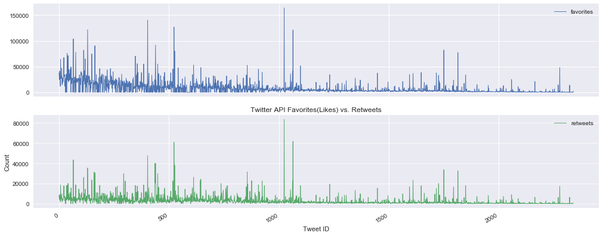

```python
twt_df_cln[['favorites', 'retweets']].plot.line(grid=True, linewidth=0.9, subplots=True,
                                                figsize=(17,7))

# adding my labels
plt.title('Twitter API Favorites(Likes) vs. Retweets')
plt.xlabel('Tweet ID')
plt.ylabel('Count')
plt.grid(axis='y', alpha=0.75)
```

**Hmm.... this is interesting. Let's take a closer look.**

```
Text(0,0.5,'Number of Retweets')
```

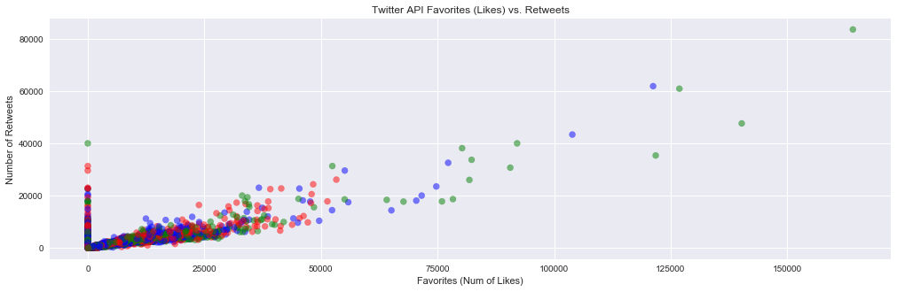

```python
x = twt_df_cln['favorites']
y = twt_df_cln['retweets']

colors = 'RGB'

plt.figure(figsize=(17, 5))
plt.scatter(x, y, c=colors, alpha=0.5)

# setting my labels
plt.title('Twitter API Favorites (Likes) vs. Retweets')
plt.xlabel('Favorites (Num of Likes)')
plt.ylabel('Number of Retweets')
```

*Image Prediction DF Analysis*

```python
img_prd_df_cln.set_index('tweet_id', inplace=True)
```

```python
img_prd_df_cln.head()
```

[output not shown]

In order to assess and analyze the difference or variance between p1 predictions and p2 or p3 predicitions, I'll create three columns that measure the variances between p1 & p2 predictions, p1 & p3 predictions, and lastly p2 & p3 predictions. I'll call these columns `p1_p2_var,` `p1_p3_var` and `p2_p3_var`.

```python
# creating my variance columns
img_prd_df_cln['p1_p2_var'] = (img_prd_df_cln['p1_conf'] - img_prd_df_cln['p2_conf'])
img_prd_df_cln['p2_p3_var'] = (img_prd_df_cln['p2_conf'] - img_prd_df_cln['p3_conf'])
img_prd_df_cln['p1_p3_var'] = (img_prd_df_cln['p1_conf'] - img_prd_df_cln['p3_conf'])
```

```python
# checking my newly created columns
img_prd_df_cln.head()
```

| tweet_id | jpg_url | img_num | p1 | p1_conf | p1_dog | p2 | p2_conf | p2_dog | p3 | p3_conf | p3_dog | p1_p2_var | p2_p3_var | p1_p3_var |
| --- | --- | --- | --- | --- | --- | --- | --- | --- | --- | --- | --- | --- | --- | --- |
| 666020888022790149 | https://pbs.twimg.com/media/CT4udn0WwAA0aMy.jpg | 1 | Welsh_springer_spaniel | 0.465074 | True | collie | 0.156665 | True | Shetland_sheepdog | 0.061428 | True | 0.308409 | 0.095237 | 0.403646 |
| 666029285002620928 | https://pbs.twimg.com/media/CT42GRgUYAA5iDo.jpg | 1 | redbone | 0.506826 | True | miniature_pinscher | 0.074192 | True | Rhodesian_ridgeback | 0.072010 | True | 0.432634 | 0.002182 | 0.434816 |
| 666033412701032449 | https://pbs.twimg.com/media/CT4521TWwAEvMyu.jpg | 1 | German_shepherd | 0.596461 | True | malinois | 0.138584 | True | bloodhound | 0.116197 | True | 0.457877 | 0.022387 | 0.480264 |
| 666044226329800704 | https://pbs.twimg.com/media/CT5Dr8HUEAA-lEu.jpg | 1 | Rhodesian_ridgeback | 0.408143 | True | redbone | 0.360687 | True | miniature_pinscher | 0.222752 | True | 0.047456 | 0.137935 | 0.185391 |
| 666049248165822465 | https://pbs.twimg.com/media/CT5IQmsXIAAKY4A.jpg | 1 | miniature_pinscher | 0.560311 | True | Rottweiler | 0.243682 | True | Doberman | 0.154629 | True | 0.316629 | 0.089053 | 0.405682 |

*Overlaying my visualization*

```
Text(0,0.5,'Frequency of Variance Value Occurring')
```

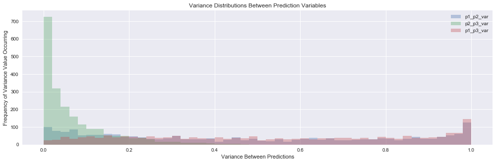

```python
img_prd_df_cln[['p1_p2_var', 'p2_p3_var', 'p1_p3_var']].plot(kind='hist',grid=True, bins=50, subplots=False,
                                                             figsize=(17,5), alpha=0.35)

# setting my labels
plt.title('Variance Distributions Between Prediction Variables')
plt.xlabel('Variance Between Predictions')
plt.ylabel('Frequency of Variance Value Occurring')
```

*Keeping my visualizations separate of one another*

```
Text(0,0.5,'Variance Amt Count')
```

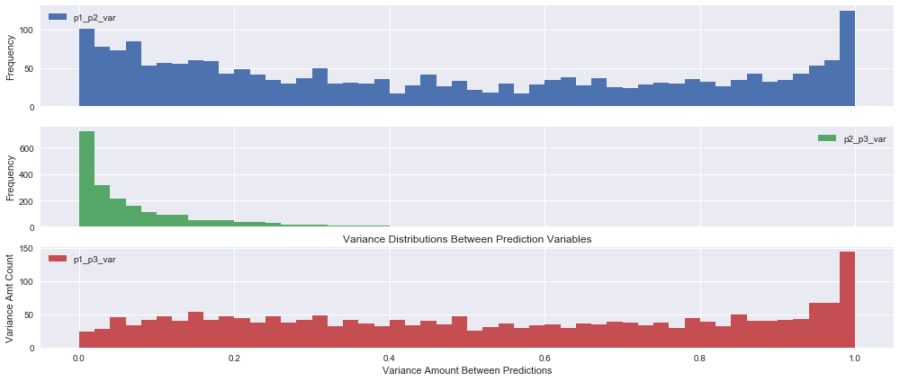

```python
img_prd_df_cln[['p1_p2_var', 'p2_p3_var', 'p1_p3_var']].plot.hist(grid=True, bins=50, subplots=True,
                                                                  figsize=(17,7))

# setting my labels
plt.title('Variance Distributions Between Prediction Variables')
plt.xlabel('Variance Amount Between Predictions')
plt.ylabel('Variance Amt Count')
```

Taking a look at the distributions between prediction confidence percentages, I noticed something a bit odd. It seems as though the range of variance, in terms of distribution of variances or differences in prediction percentages, are far less for `p2_conf` and `p3_conf` variables, ranging from 0.0 to 0.4. This seems to make sense however, as `p2_conf` and `p3_conf` are weaker prediction percentages, compared to `p1_conf` values.

*Plotting my melted Image Prediction DF 2*

```python
img_pred_df_cpy_2.head()
```

|  | tweet_id | prediction | dg_brd_pred | pred_pct | pred_outcm | jpg_url | img_num |
| --- | --- | --- | --- | --- | --- | --- | --- |
| 0 | 666020888022790149 | p1 | Welsh springer spaniel | 0.465074 | True | https://pbs.twimg.com/media/CT4udn0WwAA0aMy.jpg | 1 |
| 1 | 666029285002620928 | p1 | redbone | 0.506826 | True | https://pbs.twimg.com/media/CT42GRgUYAA5iDo.jpg | 1 |
| 2 | 666033412701032449 | p1 | German shepherd | 0.596461 | True | https://pbs.twimg.com/media/CT4521TWwAEvMyu.jpg | 1 |
| 3 | 666044226329800704 | p1 | Rhodesian ridgeback | 0.408143 | True | https://pbs.twimg.com/media/CT5Dr8HUEAA-lEu.jpg | 1 |
| 4 | 666049248165822465 | p1 | miniature pinscher | 0.560311 | True | https://pbs.twimg.com/media/CT5IQmsXIAAKY4A.jpg | 1 |

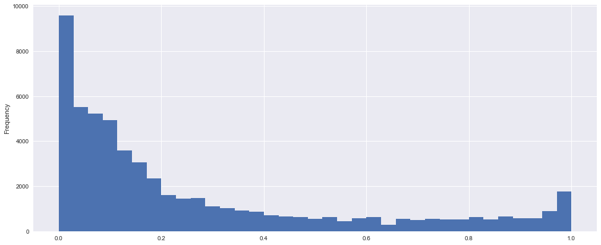

```python
img_pred_df_cpy_2['pred_pct'].plot(kind='hist', bins=35, figsize=(17, 7));
```

*Twitter Archive DF Analysis*

```python
twt_ar_df_cln.info()
```

```
<class 'pandas.core.frame.DataFrame'>
Int64Index: 2097 entries, 0 to 2355
Data columns (total 9 columns):
tweet_id              2097 non-null int64
timestamp             2097 non-null datetime64[ns]
source                2097 non-null object
text                  2097 non-null object
rating_numerator      2096 non-null float64
rating_denominator    2097 non-null int64
name                  1321 non-null object
tweet_status_url      2097 non-null object
dog_stage             2097 non-null object
dtypes: datetime64[ns](1), float64(1), int64(2), object(5)
memory usage: 243.8+ KB
```

```python
twt_ar_df_cln.head(1)
```

|  | tweet_id | timestamp | source | text | rating_numerator | rating_denominator | name | tweet_status_url | dog_stage |
| --- | --- | --- | --- | --- | --- | --- | --- | --- | --- |
| 0 | 892420643555336193 | 2017-08-01 16:23:56 | "http://twitter.com/download/iphone" rel="nofollow" Twitter for iPhone | This is Phineas. He's a mystical boy. Only ever appears in the hole of a donut. 13/10 | 13.0 | 10 | Phineas | https://twitter.com/dog_rates/status/892420643555336193/photo/1 |  |

```python
# taking a look at value counts for the 'source' column
twt_ar_df_cln['source'].value_counts()
```

```
"http://twitter.com/download/iphone" rel="nofollow" Twitter for iPhone     1964
"http://vine.co" rel="nofollow" Vine - Make a Scene                          91
"http://twitter.com" rel="nofollow" Twitter Web Client                       31
"https://about.twitter.com/products/tweetdeck" rel="nofollow" TweetDeck      11
Name: source, dtype: int64
```

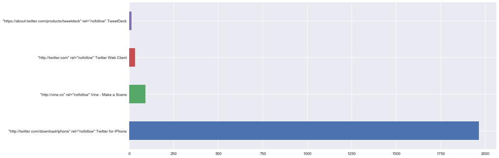

```python
twt_ar_df_cln['source'].value_counts().plot(kind='barh', figsize=(17, 7))
```

*Twitter Archive Combined Data Set Analysis*

```python
twt_data_cmbd_df.columns
```

```
Index(['tweet_id', 'timestamp', 'source', 'text', 'rating_numerator',
       'rating_denominator', 'name', 'tweet_status_url', 'dog_stage',
       'jpg_url', 'img_num', 'p1', 'p1_conf', 'p1_dog', 'p2', 'p2_conf',
       'p2_dog', 'p3', 'p3_conf', 'p3_dog', 'favorites', 'favorited',
       'retweets', 'retweeted'],
      dtype='object')
```

```python
# taking a look at the prediction confidence means for dog stages
twt_data_cmbd_df.groupby('dog_stage')[['p1_conf', 'p2_conf', 'p3_conf']].mean()
```

| dog_stage | p1_conf | p2_conf | p3_conf |
| --- | --- | --- | --- |
|  | 0.601870 | 0.134299 | 0.059365 |
| doggo | 0.592996 | 0.113622 | 0.058803 |
| doggo, pupper | 0.495202 | 0.203103 | 0.080413 |
| floofer | 0.444456 | 0.185075 | 0.084119 |
| pupper | 0.591276 | 0.132654 | 0.060284 |
| pupper, doggo | 0.597111 | 0.142993 | 0.136712 |
| pupper, doggo, doggo | 0.869804 | 0.079814 | 0.013263 |
| pupper, pupper | 0.446901 | 0.190128 | 0.080244 |
| pupper, pupper, pupper | 0.186498 | 0.139028 | 0.125940 |
| puppo | 0.594364 | 0.127601 | 0.065903 |
| puppo, doggo | 0.723313 | 0.218477 | 0.041277 |

```python
dg_stg_cnf_mns = twt_data_cmbd_df.groupby('dog_stage')[['p1_conf', 'p2_conf', 'p3_conf']].mean()
```

```
Text(0,0.5,'Prediction Confidence Percentage')
```

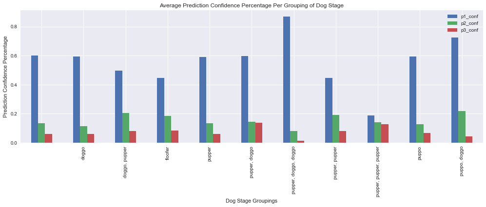

```python
dg_stg_cnf_mns.plot(kind='bar', figsize=(17, 5))

# setting my labels
plt.title('Average Prediction Confidence Percentage Per Grouping of Dog Stage')
plt.xlabel('Dog Stage Groupings')
plt.ylabel('Prediction Confidence Percentage')
```

Ok, so here we have grouped the dog stages by the column `dog_stage`'s values. I've plotted the mean or average prediction values for each dog stage grouping. We can see the grouping 'pupper, doggo, doggo' has the highest confidence percentage for p1 predictions at .87 or 87%. On the reverse, it looks like the grouping 'pupper, pupper, pupper' has the lowest p1 confidence percentage mean at .19 or 19%.

```python
# taking a look at the 'favorites' or likes and 'retweets' count for various dog stage groupings
twt_data_cmbd_df.groupby('dog_stage')[['favorites', 'retweets']].mean()
```

| dog_stage | favorites | retweets |
| --- | --- | --- |
|  | 7515.547454 | 2796.396412 |
| doggo | 11042.693333 | 4095.746667 |
| doggo, pupper | 6595.200000 | 2040.000000 |
| floofer | 12358.500000 | 4328.250000 |
| pupper | 5741.343478 | 2005.821739 |
| pupper, doggo | 7512.000000 | 3132.000000 |
| pupper, doggo, doggo | 6867.000000 | 1308.000000 |
| pupper, pupper | 4458.285714 | 1534.000000 |
| pupper, pupper, pupper | 770.000000 | 176.000000 |
| puppo | 15751.222222 | 5148.296296 |
| puppo, doggo | 25027.000000 | 5861.000000 |

```python
dg_stg_fv_vs_rt_mns = twt_data_cmbd_df.groupby('dog_stage')[['favorites', 'retweets']].mean()
```

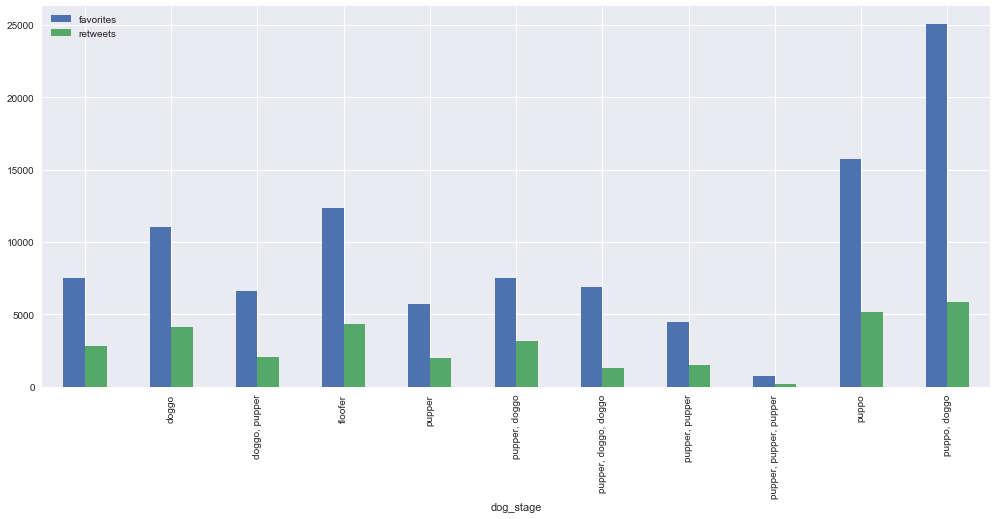

```python
dg_stg_fv_vs_rt_mns.plot(kind='bar', figsize=(17, 7))
```

```python
# taking a look at the 'favorites' or likes and 'retweets' 'describe()' method for various dog stage groupings
twt_data_cmbd_df.groupby('dog_stage')[['favorites', 'retweets']].describe()
```

| dog_stage | favorites count | favorites mean | favorites std | favorites min | favorites 25% | favorites 50% | favorites 75% | favorites max | retweets count | retweets mean | retweets std | retweets min | retweets 25% | retweets 50% | retweets 75% | retweets max |
| --- | --- | --- | --- | --- | --- | --- | --- | --- | --- | --- | --- | --- | --- | --- | --- | --- |
|  | 1728.0 | 7515.547454 | 12480.481363 | 0.0 | 1189.50 | 3146.5 | 8512.50 | 164076.0 | 1728.0 | 2796.396412 | 5089.099220 | 0.0 | 530.00 | 1206.5 | 3150.0 | 83532.0 |
| doggo | 75.0 | 11042.693333 | 10037.490869 | 0.0 | 3754.00 | 10294.0 | 14571.00 | 55081.0 | 75.0 | 4095.746667 | 4527.902274 | 3.0 | 1506.00 | 2409.0 | 5233.5 | 22746.0 |
| doggo, pupper | 5.0 | 6595.200000 | 3358.738260 | 3194.0 | 4156.00 | 5493.0 | 8996.00 | 11137.0 | 5.0 | 2040.000000 | 1014.318244 | 906.0 | 1317.00 | 2082.0 | 2374.0 | 3521.0 |
| floofer | 4.0 | 12358.500000 | 16357.668834 | 0.0 | 4390.50 | 6492.5 | 14460.50 | 36449.0 | 4.0 | 4328.250000 | 2965.830449 | 1668.0 | 1826.25 | 4201.0 | 6703.0 | 7243.0 |
| pupper | 230.0 | 5741.343478 | 8260.283845 | 0.0 | 1878.75 | 3218.0 | 5445.25 | 77280.0 | 230.0 | 2005.821739 | 3280.421152 | 4.0 | 599.25 | 1071.0 | 1978.0 | 32601.0 |
| pupper, doggo | 1.0 | 7512.000000 | NaN | 7512.0 | 7512.00 | 7512.0 | 7512.00 | 7512.0 | 1.0 | 3132.000000 | NaN | 3132.0 | 3132.00 | 3132.0 | 3132.0 | 3132.0 |
| pupper, doggo, doggo | 1.0 | 6867.000000 | NaN | 6867.0 | 6867.00 | 6867.0 | 6867.00 | 6867.0 | 1.0 | 1308.000000 | NaN | 1308.0 | 1308.00 | 1308.0 | 1308.0 | 1308.0 |
| pupper, pupper | 7.0 | 4458.285714 | 5337.792075 | 972.0 | 1957.50 | 2705.0 | 3632.00 | 16352.0 | 7.0 | 1534.000000 | 2101.493517 | 156.0 | 522.00 | 652.0 | 1355.0 | 6176.0 |
| pupper, pupper, pupper | 1.0 | 770.000000 | NaN | 770.0 | 770.00 | 770.0 | 770.00 | 770.0 | 1.0 | 176.000000 | NaN | 176.0 | 176.00 | 176.0 | 176.0 | 176.0 |
| puppo | 27.0 | 15751.222222 | 18404.833747 | 0.0 | 6041.50 | 11740.0 | 18843.00 | 92065.0 | 27.0 | 5148.296296 | 7363.552674 | 169.0 | 2535.00 | 3391.0 | 4814.0 | 40029.0 |
| puppo, doggo | 2.0 | 25027.000000 | 6798.124594 | 20220.0 | 22623.50 | 25027.0 | 27430.50 | 29834.0 | 2.0 | 5861.000000 | 1750.796390 | 4623.0 | 5242.00 | 5861.0 | 6480.0 | 7099.0 |

```python
twt_data_cmd_dscr_sts = twt_data_cmbd_df.groupby('dog_stage')[['favorites', 'retweets']].describe()
```

```python
twt_data_cmd_dscr_sts.index
```

```
Index(['', 'doggo', 'doggo, pupper', 'floofer', 'pupper', 'pupper, doggo',
       'pupper, doggo, doggo', 'pupper, pupper', 'pupper, pupper, pupper',
       'puppo', 'puppo, doggo'],
      dtype='object', name='dog_stage')
```

```
No handles with labels found to put in legend.
```

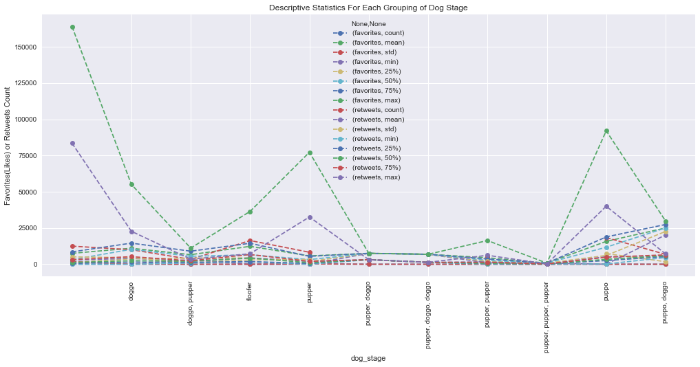

```python
# setting my labels for the graph
ticklabels = list(twt_data_cmbd_df['dog_stage'])

# creating my matplotlib object
twt_data_cmd_dscr_sts_fig, ax = plt.subplots(figsize=(17, 7))

# setting the labels on my matplotlib object
ax.set_xticks(np.arange(1,12))
ax.set_xticklabels(ticklabels)
ax.set_xlabel('Dog Stage Groupings')
ax.set_ylabel('Favorites(Likes) or Retweets Count')
ax.set_title('Descriptive Statistics For Each Grouping of Dog Stage')
ax.legend(loc='center left', frameon=False, ncol=4)
twt_data_cmd_dscr_sts.plot(kind='line', ax=ax, label=ticklabels, rot=90, legend=True, marker='o',
                           style='--', figsize=(17, 7));
```

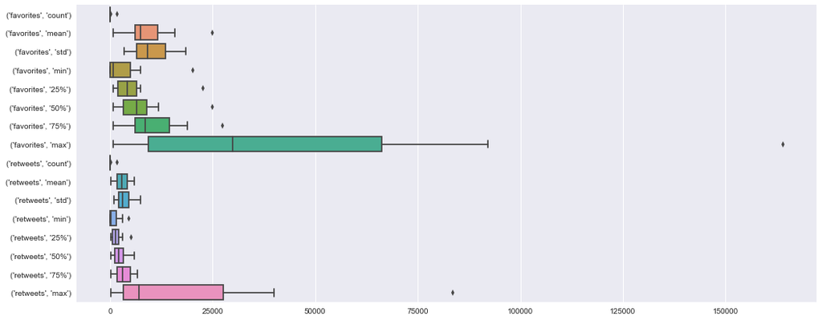

```python
# plotting with seaborn, the same descriptive statistics from above.
fig, ax = plt.subplots(figsize=(17, 7))

sns.boxplot(data=twt_data_cmd_dscr_sts, ax=ax, orient='h')
```

### Resources

- Udacity Data Analyst course material
- Google/Stackoverflow
- Python: Crash Course by Eric Matthes